# Book exercises

Author

Daniela Palleschi

# Set options

```r
# set global knit options
knitr::opts_chunk$set(echo = T,
                      eval = T,
                      error = F,
                      warning = F,
                      message = F,
                      cache = T)

# suppress scientific notation
options(scipen=999)

# list of required packages
packages <- c( #"SIN", # this package was removed from the CRAN repository
               "MASS", "dplyr", "tidyr", "purrr", "extraDistr", "ggplot2", "loo", "bridgesampling", "brms", "bayesplot", "tictoc", "hypr", "bcogsci", "papaja", "grid", "kableExtra", "gridExtra", "lme4", "cowplot", "pdftools", "cmdstanr", "rootSolve", "rstan"
  )

# NB: if you haven't already installed bcogsci through devtools, it won't be loaded
## Now load or install & load all
package.check <- lapply(
  packages,
  FUN = function(x) {
    if (!require(x, character.only = TRUE)) {
      install.packages(x, dependencies = TRUE)
      library(x, character.only = TRUE)
    }
  }
)

# this is also required, taken from the textbook

## Save compiled models:
rstan_options(auto_write = FALSE)
## Parallelize the chains using all the cores:
options(mc.cores = parallel::detectCores())
# To solve some conflicts between packages
select <- dplyr::select
extract <- rstan::extract
```

# 1 Chapter 1 - Introduction

## Exercise 1.1 Practice using the pnorm function - Part 1

Given a normal distribution with mean 500 and standard deviation 100, use the pnorm function to calculate the probability of obtaining values between 200 and 800 from this distribution.

```r
pnorm(800, 500, 100) - pnorm(200, 500, 100)
```

```
[1] 0.9973002
```

## Exercise 1.2 Practice using the pnorm function - Part 2

Calculate the following probabilities. Given a normal distribution with mean 800 and standard deviation 150, what is the probability of obtaining:

- a score of 700 or less
- a score of 900 or more
- a score of 800 or more

```r
# 700 or more
pnorm(700,800,150)
```

```
[1] 0.2524925
```

```r
# 900, 800 or more
pnorm(c(900,800), 800,150, lower.tail=F)
```

```
[1] 0.2524925 0.5000000
```

## Exercise 1.3 Practice using the pnorm function - Part 3

Given a normal distribution with mean 600 and standard deviation 200, what is the probability of obtaining:

- a score of 550 or less.
- a score between 300 and 800.
- a score of 900 or more.

```r
# 550 or less
pnorm(q = 550,
      m = 600, sd = 200)
```

```
[1] 0.4012937
```

```r
# 300-800
pnorm(q = 800,
      m = 600, sd = 200) - pnorm(q = 300, m = 600, sd = 200)
```

```
[1] 0.7745375
```

```r
# 900 or more
pnorm(q = 900,
      m = 600, sd = 200, lower.tail=F)
```

```
[1] 0.0668072
```

## Exercise 1.4 Practice using the qnorm function - Part 1

Consider a normal distribution with mean 1 and standard deviation 1. Compute the lower and upper boundaries such that:

- the area (the probability) to the left of the lower boundary is 0.10.
- the area (the probability) to the left of the upper boundary is 0.90.

```r
# lower bound is .1
qnorm(p = .1,
      mean = 1, sd = 1)
```

```
[1] -0.2815516
```

```r
# lower bound is .9
qnorm(p = .9,
      mean = 1, sd = 1)
```

```
[1] 2.281552
```

## Exercise 1.5 Practice using the qnorm function - Part 2

Given a normal distribution with mean 650 and standard deviation 125. There exist two quantiles, the lower quantile q1 and the upper quantile q2, that are equidistant from the mean 650, such that the area under the curve of the normal between q1 and q2 is 80%. Find q1 and q2.

```r
q1 <- qnorm(p =.1,
            mean = 650, sd = 125)
q2 <- qnorm(p =.9,
            mean = 650, sd = 125)
q1; q2
```

```
[1] 489.8061
```

```
[1] 810.1939
```

```r
# check this is right
pnorm(q = q2,
      m = 650, sd = 125) - pnorm(q = q1, m = 650, sd = 125)
```

```
[1] 0.8
```

## Exercise 1.6 Practice getting summaries from samples - Part 1

Given data that is generated as follows:

```r
data_gen1 <- rnorm(1000, 300, 200)
```

Calculate the mean, variance, and the lower quantile q1 and the upper quantile q2, that are equidistant and such that the range of probability between them is 80%.

```r
mean <- mean(data_gen1)
sd <- sd(data_gen1)

q1 <- qnorm(.1,
            mean,sd)
q2 <- qnorm(.9,
            mean,sd)
q1; q2
```

```
[1] 28.95491
```

```
[1] 559.7184
```

```r
# check
pnorm(q2,mean,sd) - pnorm(q1,mean,sd)
```

```
[1] 0.8
```

## Exercise 1.7 Practice getting summaries from samples - Part 2.

This time we generate the data with a truncated normal distribution from the package extraDistr. The details of this distribution will be discussed later in section 4.1 and in the Box 4.1, but for now we can treat it as an unknown generative process:

```r
data_gen1 <- extraDistr::rtnorm(1000, 300, 200, a = 0)
```

Calculate the mean, variance, and the lower quantile q1 and the upper quantile q2, that are equidistant and such that the range of probability between them is 80%.

```r
mean <- mean(data_gen1)
sd <- sd(data_gen1)

q1 <- qnorm(.1,
            mean,sd)
q2 <- qnorm(.9,
            mean,sd)
q1; q2
```

```
[1] 103.6784
```

```
[1] 555.12
```

```r
# check
pnorm(q2,mean,sd) - pnorm(q1,mean,sd)
```

```
[1] 0.8
```

## Exercise 1.8 Practice with a variance-covariance matrix for a bivariate distribution.

Suppose that you have a bivariate distribution where one of the two random variables comes from a normal distribution with mean $\mu$X = 600 and standard deviation $\sigma$X = 100, and the other from a normal distribution with mean $\mu$Y = 400 and standard deviation $\sigma$Y = 50. The correlation $\rho$XY between the two random variables is 0.4. Write down the variance-covariance matrix of this bivariate distribution as a matrix (with numerical values, not mathematical symbols), and then use it to generate 100 pairs of simulated data points.

```r
# generate simulated bivariate data

## define two RVs

## define a VarCorr matrix, where rho = .6, variance
Sigma <- matrix(c(
  100^2, 100 * 50 * .4,
  100 * 50 * .4, 100^2
  ),
  byrow = F, ncol = 2
  )

## generate data
u <- as.data.frame(MASS::mvrnorm(n = 100, mu = c(600,400), Sigma = Sigma))
head(u, n=3)
```

```
        V1       V2
1 578.4461 447.5256
2 612.7572 485.4886
3 611.9357 589.0848
```

Plot the simulated data such that the relationship between the random variables X and Y is clear.

Generate two sets of new data (100 pairs of data points each) with correlation −0.4 and 0, and plot these alongside the plot for the data with correlation 0.4.

```r
# generate simulated bivariate data
rho <- -.4
## define a VarCorr matrix, where rho = 0, variance
Sigma <- matrix(c(
  100^2, 100 * 50 * rho,
  100 * 50 * rho, 100^2
  ),
  byrow = F, ncol = 2
  )

## generate data
u4 <- as.data.frame(MASS::mvrnorm(n = 100, mu = c(600,400), Sigma = Sigma))

# generate simulated bivariate data
rho <- 0
## define a VarCorr matrix, where rho = 0, variance
Sigma <- matrix(c(
  100^2, 100 * 50 * rho,
  100 * 50 * rho, 100^2
  ),
  byrow = F, ncol = 2
  )

## generate data
u0 <- as.data.frame(MASS::mvrnorm(n = 100, mu = c(600,400), Sigma = Sigma))
```

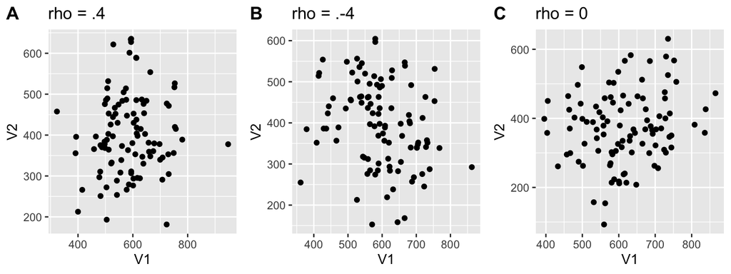

```r
ggpubr::ggarrange(
  ggplot2::ggplot(u, aes(x = V1, y = V2)) +
    labs(title = "rho = .4") +
    geom_point(),
  ggplot2::ggplot(u4, aes(x = V1, y = V2)) +
    labs(title ="rho = .-4") +
    geom_point(),
  ggplot2::ggplot(u0, aes(x = V1, y = V2)) +
    labs(title ="rho = 0") +
    geom_point(),
  nrow = 1, labels = c("A", "B", "C")
)
```

# 2 Chapter 2 - Intro to Bayesian data analysis

#### 2.3 Conjugate forms 2

Suppose you have $n$ independent and identically distributed data points from the Geometric distribution, which has the likelihood function

$$\begin{equation}
f(x|\theta)=\theta(1-\theta)^{\sum_{i=1}^n x_i}
\end{equation}$$

where the data points $x$ can have values 0,1,2,. Let the prior on $\theta$ be $Beta(a,b)$, a beta distribution with parameters a,b. The posterior distribution is a beta distribution with parameters a* and b*. Determine these parameters in terms of $a, b,$ and $\sum_{i=1}^n x_i$.

My work:

- prior is $Beta(a,b)$
- likelihood is $\theta(1-\theta)\sum_{i=1}^n x_i$
- posterior up to proportionality is$[\theta^{a-1}(1-\theta)^{b-1}][\theta(1-\theta)\sum_{i=1}^n x_i$
- sum up the exponentials on either side (and if there’s no exponential then add a +1 cause every number is to the power of 1): $\theta^{a + 1 - 1}(1-\theta)^{b + \sum_{i=1}^n x_i - 1}$
- and cancel out the $^{-1}$: $\theta^{a + 1}(1-\theta)^{b + \sum_{i=1}^n x_i}$

# 3 Chapter 3

# 4 Chapter 4

# 5 Chapter 5 - Bayesian hierachical models

```r
data("df_pupil_complete")
df_pupil_complete
```

```
# A tibble: 2,228 × 4
    subj trial  load p_size
   <int> <int> <int>  <dbl>
 1   701     1     2  1021.
 2   701     2     1   951.
 3   701     3     5  1064.
 4   701     4     4   913.
 5   701     5     0   603.
 6   701     6     3   826.
 7   701     7     0   464.
 8   701     8     4   758.
 9   701     9     2   733.
10   701    10     3   591.
# … with 2,218 more rows
```

You should be able to now fit a “maximal” model (correlated varying intercept and slopes for subjects) assuming a normal likelihood. Base your priors in the priors discussed in section 4.1.

**Maximal model**

- first centre the predictor

```r
df_pupil_complete <- df_pupil_complete %>%
  mutate(c_load = load-mean(load))
```

- then run the model

```r
fit_pupil <- brm(p_size ~ 1 + c_load +
                   (1 +c_load | subj),
                 data = df_pupil_complete,
                 family = gaussian(),
                 prior = c(
                   prior(normal(1000, 500), class = Intercept),
                   prior(normal(0, 1000), class = sigma),
                   prior(normal(0, 100), class = b, coef = c_load),
                   prior(normal(0, 1000), class = sd),
                   prior(lkj(2), class = cor)
                 ) )
```

[output not shown]

1. Examine the effect of load on pupil size, and the average pupil size. What do you conclude?

**My solution**

```r
fit_pupil
```

```
 Family: gaussian
  Links: mu = identity; sigma = identity
Formula: p_size ~ 1 + c_load + (c_load | subj)
   Data: df_pupil_complete (Number of observations: 2228)
  Draws: 4 chains, each with iter = 2000; warmup = 1000; thin = 1;
         total post-warmup draws = 4000

Group-Level Effects:
~subj (Number of levels: 20)
                      Estimate Est.Error l-95% CI u-95% CI Rhat Bulk_ESS
sd(Intercept)          3332.71    416.73  2574.06  4208.37 1.00      928
sd(c_load)               71.33     15.18    47.66   105.57 1.00     1049
cor(Intercept,c_load)     0.31      0.24    -0.20     0.71 1.00     1684
                      Tail_ESS
sd(Intercept)             1340
sd(c_load)                1521
cor(Intercept,c_load)     2299

Population-Level Effects:
          Estimate Est.Error l-95% CI u-95% CI Rhat Bulk_ESS Tail_ESS
Intercept  2427.93    473.20  1490.65  3322.08 1.00      733     1133
c_load       37.85     24.67   -12.65    84.40 1.00     1349     1768

Family Specific Parameters:
      Estimate Est.Error l-95% CI u-95% CI Rhat Bulk_ESS Tail_ESS
sigma   505.26      7.64   490.55   520.07 1.00     5853     3063

Draws were sampled using sampling(NUTS). For each parameter, Bulk_ESS
and Tail_ESS are effective sample size measures, and Rhat is the potential
scale reduction factor on split chains (at convergence, Rhat = 1).
```

- 95% CrI crosses 0: quite a bit of uncertainty
- alternatively, to only print `c_load`

```r
posterior_summary(fit_pupil, variable = "b_c_load")
```

```
         Estimate Est.Error      Q2.5   Q97.5
b_c_load 37.84521  24.67261 -12.65144 84.4003
```

- but the intercept is quite large:

```r
posterior_summary(fit_pupil, variable = "b_Intercept")
```

```
            Estimate Est.Error     Q2.5    Q97.5
b_Intercept 2427.935  473.2012 1490.647 3322.082
```

- even though we assumed it wouldn’t be

```r
brms::prior_summary(fit_pupil)
```

```
                prior     class      coef group resp dpar nlpar lb ub
               (flat)         b
       normal(0, 100)         b    c_load
    normal(1000, 500) Intercept
 lkj_corr_cholesky(2)         L
 lkj_corr_cholesky(2)         L            subj
      normal(0, 1000)        sd                                  0
      normal(0, 1000)        sd            subj                  0
      normal(0, 1000)        sd    c_load  subj                  0
      normal(0, 1000)        sd Intercept  subj                  0
      normal(0, 1000)     sigma                                  0
       source
      default
         user
         user
         user
 (vectorized)
         user
 (vectorized)
 (vectorized)
 (vectorized)
         user
```

- overly informative prior for the intercept?
2. Do a sensitivity analysis for the prior on the intercept ($\alpha$). What is the estimate of the effect ($\beta$) under different priors?

**My solution**

- try a *wider* prior for $\alpha$; I’m choosing 3000 and 1000ms

$$\alpha \sim Normal(3000,1000)$$

```r
fit_pupil_2 <- brm(p_size ~ 1 + c_load +
                   (1 + c_load | subj),
                 data = df_pupil_complete,
                 family = gaussian(),
                 prior = c(
                   prior(normal(3000, 1000), class = Intercept),
                   prior(normal(0, 1000), class = sigma),
                   prior(normal(0, 100), class = b, coef = c_load),
                   prior(normal(0, 1000), class = sd),
                   prior(lkj(2), class = cor)
                 ) )
```

[output not shown]

```r
posterior_summary(fit_pupil_2, variable = "b_c_load")
```

```
         Estimate Est.Error     Q2.5    Q97.5
b_c_load 55.51111  17.24948 19.16329 87.87106
```

- the effect of `c_load` now ha more certainty

```r
posterior_summary(fit_pupil, variable = "b_Intercept")
```

```
            Estimate Est.Error     Q2.5    Q97.5
b_Intercept 2427.935  473.2012 1490.647 3322.082
```

3. Is the effect of load consistent across subjects? Investigate this visually.

**My solution**

- check out overall effect; there are 3 peaks

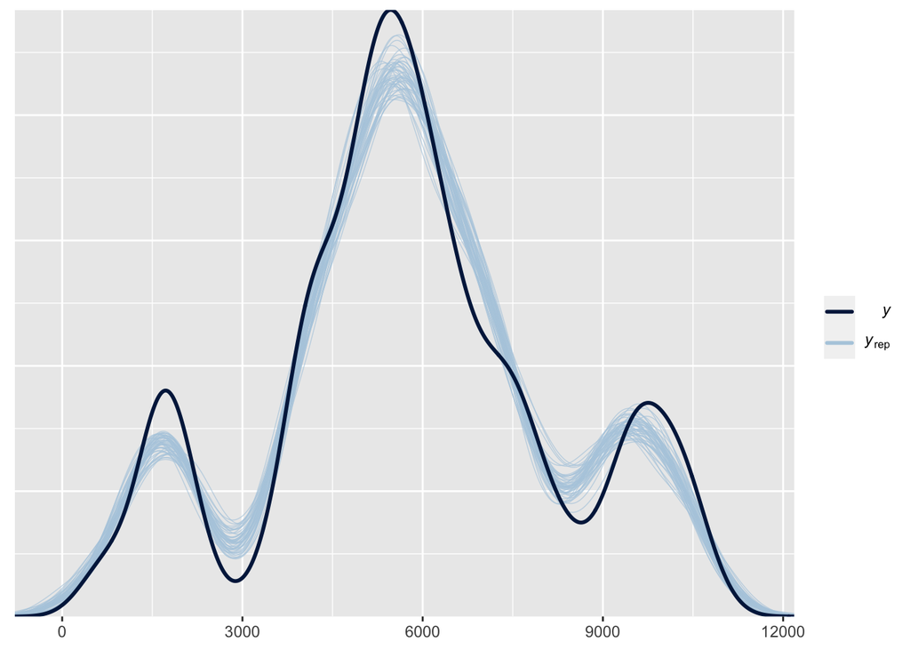

```r
pp_check(fit_pupil_2, ndraws = 50, type = "dens_overlay")
```

- now by participants

[figure not shown]

```r
ppc_dens_overlay_grouped(df_pupil_complete$p_size,
  yrep =
    posterior_predict(fit_pupil_2,
      ndraws = 100
    ),
  group = df_pupil_complete$subj
) +
  xlab("Signal in the N400 spatiotemporal window")
```

- and by sd

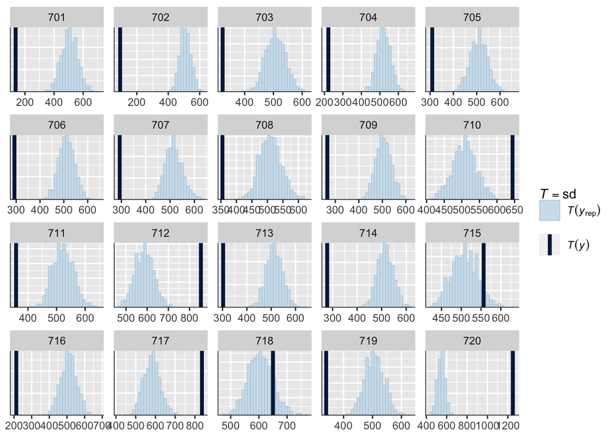

```r
pp_check(fit_pupil_2,
  type = "stat_grouped",
  ndraws = 1000,
  group = "subj",
  stat = "sd"
)
```

- and also:

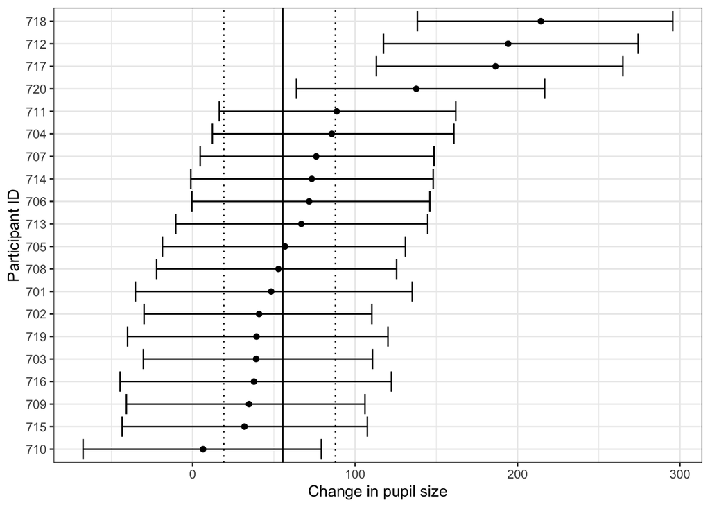

```r
## For the hierarchical model is more complicated, # because we want the effect (beta) + adjustment: # we extract the overall group level effect:
beta <- c(as_draws_df(fit_pupil_2)$b_c_load)
# We extract the individual adjustments
ind_effects_v <- paste0("r_subj[", unique(df_pupil_complete$subj), ",c_load]")
adjustment <- as.matrix(as_draws_df(fit_pupil)[ind_effects_v])
# We get the by subject effects in a data frame where each adjustment # is in each column.
by_subj_effect <- as_tibble(beta + adjustment)
# We summarize them by getting a table with the mean and the
# quantiles for each column and then binding them.
par_h <- lapply(by_subj_effect, function(x) {
  tibble(
    Estimate = mean(x),
    Q2.5 = quantile(x, .025),
    Q97.5 = quantile(x, .975)
  )
}) %>%
  bind_rows() %>%
  # We add a column to identify that the model, # and one with the subject labels:
  mutate(subj = unique(df_pupil_complete$subj)) %>% arrange(Estimate) %>%
  mutate(subj = factor(subj, levels = subj))
ggplot(par_h,
       aes(
         ymin = Q2.5,
         ymax = Q97.5,
         x = subj,
         y = Estimate
       )) +
  geom_errorbar() +
  geom_point() +
  # We'll also add the mean and 95% CrI of the overall difference # to the plot:
  geom_hline(yintercept =
               posterior_summary(fit_pupil_2)["b_c_load", "Estimate"]) +
  geom_hline(
    yintercept =
      posterior_summary(fit_pupil_2)["b_c_load", "Q2.5"],
    linetype = "dotted",
    linewidth = .5
  ) + geom_hline(
    yintercept =
      posterior_summary(fit_pupil_2)["b_c_load", "Q97.5"],
    linetype = "dotted",
    linewidth = .5
  ) +
  coord_flip() +
  ylab("Change in pupil size") +
  xlab("Participant ID") +
  theme_bw()
```

## 5.2 Exercise 5.2 Are subject relatives easier to process than object relatives (log-normal likelihood)?

We begin with a classic question from the psycholinguistics literature: Are subject relatives easier to process than object relatives? The data come from Experiment 1 in a paper by Grodner and Gibson (2005).

Scientific question: Is there a subject relative advantage in reading?

Grodner and Gibson (2005) investigate an old claim in psycholinguistics that object relative clause (ORC) sentences are more difficult to process than subject relative clause (SRC) sentences. One explanation for this predicted difference is that the distance between the relative clause verb (sent in the example below) and the head noun phrase of the relative clause (reporter in the example below) is longer in ORC vs. SRC. Examples are shown below. The relative clause is shown in square brackets.

(1a) The reporter [who the photographer sent to the editor] was hoping for a good story. (ORC)

(1b) The reporter [who sent the photographer to the editor] was hoping for a good story. (SRC)

The underlying explanation has to do with memory processes: Shorter linguistic dependencies are easier to process due to either reduced interference or decay, or both. For implemented computational models that spell this point out, see Lewis and Vasishth (2005) and Engelmann, Jäger, and Vasishth (2020).

In the Grodner and Gibson data, the dependent measure is reading time at the relative clause verb, (e.g., sent) of different sentences with either ORC or SRC. The dependent variable is in milliseconds and was measured in a self-paced reading task. Self-paced reading is a task where subjects read a sentence or a short text word-by-word or phrase-by-phrase, pressing a button to get each word or phrase displayed; the preceding word disappears every time the button is pressed. In 6.1, we provide a more detailed explanation of this experimental method.

For this experiment, we are expecting longer reading times at the relative clause verbs of ORC sentences in comparison to the relative clause verb of SRC sentences.

```r
data("df_gg05_rc")
df_gg05_rc
```

```
# A tibble: 672 × 7
    subj  item condition    RT residRT qcorrect experiment
   <int> <int> <chr>     <int>   <dbl>    <int> <chr>
 1     1     1 objgap      320  -21.4         0 tedrg3
 2     1     2 subjgap     424   74.7         1 tedrg2
 3     1     3 objgap      309  -40.3         0 tedrg3
 4     1     4 subjgap     274  -91.2         1 tedrg2
 5     1     5 objgap      333   -8.39        1 tedrg3
 6     1     6 subjgap     266  -87.3         1 tedrg2
 7     1     7 objgap      327  -42.2         1 tedrg3
 8     1     8 subjgap     279  -90.2         1 tedrg2
 9     1     9 objgap      342  -23.2         1 tedrg3
10     1    10 subjgap     297  -52.3         0 tedrg2
# … with 662 more rows
```

You should use a sum coding for the predictors. Here, object relative clauses (“objgaps”) are coded +1, subject relative clauses -1.

**Set contrasts**

```r
df_gg05_rc$condition <- factor(df_gg05_rc$condition, levels = c("subjgap","objgap"))
class(df_gg05_rc$condition)
```

```
[1] "factor"
```

```r
contrasts(df_gg05_rc$condition) <- c(-.5,+.5)
contrasts(df_gg05_rc$condition)
```

```
        [,1]
subjgap -0.5
objgap   0.5
```

- or, as in the book:

```r
df_gg05_rc <- df_gg05_rc %>%
  mutate(c_cond = if_else(condition == "objgap", .5, -.5))
```

You should be able to now fit a “maximal” model (correlated varying intercept and slopes for subjects and for items) assuming a log-normal likelihood.

**Maximal model**

```r
fit_df_gg05_rc <-
  brm(
    RT ~ condition + (condition |
                     subj) + (condition | item),
    family = lognormal(),
    prior =
      c(
        prior(normal(6, 1.5), class = Intercept),
        prior(normal(0, .1), class = b),
        prior(normal(0, 1), class = sigma),
        prior(normal(0, 1), class = sd),
        prior(lkj(2), class = cor)
      ),
    data = df_gg05_rc
  )

fit_df_gg05_rc
```

```
 Family: lognormal
  Links: mu = identity; sigma = identity
Formula: RT ~ condition + (condition | subj) + (condition | item)
   Data: df_gg05_rc (Number of observations: 672)
  Draws: 4 chains, each with iter = 2000; warmup = 1000; thin = 1;
         total post-warmup draws = 4000

Group-Level Effects:
~item (Number of levels: 16)
                          Estimate Est.Error l-95% CI u-95% CI Rhat Bulk_ESS
sd(Intercept)                 0.04      0.02     0.00     0.09 1.00     1218
sd(condition1)                0.09      0.05     0.01     0.19 1.00     1176
cor(Intercept,condition1)     0.27      0.40    -0.62     0.89 1.00     1894
                          Tail_ESS
sd(Intercept)                 1770
sd(condition1)                1304
cor(Intercept,condition1)     2064

~subj (Number of levels: 42)
                          Estimate Est.Error l-95% CI u-95% CI Rhat Bulk_ESS
sd(Intercept)                 0.33      0.04     0.26     0.42 1.01      867
sd(condition1)                0.23      0.04     0.15     0.32 1.00     1391
cor(Intercept,condition1)     0.51      0.16     0.16     0.79 1.00     1652
                          Tail_ESS
sd(Intercept)                 1447
sd(condition1)                2478
cor(Intercept,condition1)     2445

Population-Level Effects:
           Estimate Est.Error l-95% CI u-95% CI Rhat Bulk_ESS Tail_ESS
Intercept      5.88      0.05     5.77     5.98 1.01      485      766
condition1     0.10      0.05     0.01     0.19 1.00     1467     2140

Family Specific Parameters:
      Estimate Est.Error l-95% CI u-95% CI Rhat Bulk_ESS Tail_ESS
sigma     0.36      0.01     0.34     0.38 1.00     3056     2652

Draws were sampled using sampling(NUTS). For each parameter, Bulk_ESS
and Tail_ESS are effective sample size measures, and Rhat is the potential
scale reduction factor on split chains (at convergence, Rhat = 1).
```

1. Examine the effect of relative clause attachment site (the predictor `c_cond`) on reading times RT ($\beta$).

**My solution**

- the effect of RC attachment on RT on the log scale is

```r
posterior_summary(fit_df_gg05_rc, variable = "b_condition1")
```

```
              Estimate  Est.Error        Q2.5     Q97.5
b_condition1 0.1002225 0.04665774 0.006247148 0.1909658
```

2. Estimate the median difference between relative clause attachment sites in milliseconds, and report the mean and 95% CI.

**My solution**

```r
alpha <- as_draws_df(fit_df_gg05_rc)$b_Intercept
beta <- as_draws_df(fit_df_gg05_rc)$b_condition1
# Difference between object RC coded as .5 and subject RC coded as .5
effect <- exp(alpha + beta * .5) - exp(alpha + beta * -.5)
c(mean = mean(effect), quantile(effect, c(.025,.975)))
```

```
     mean      2.5%     97.5%
36.164531  2.218118 71.291773
```

3. Do a sensitivity analysis. What is the estimate of the effect ($\beta$) under different priors? What is the difference in milliseconds between conditions under different priors?

**My solution**

- first let’s check out the fit of the model

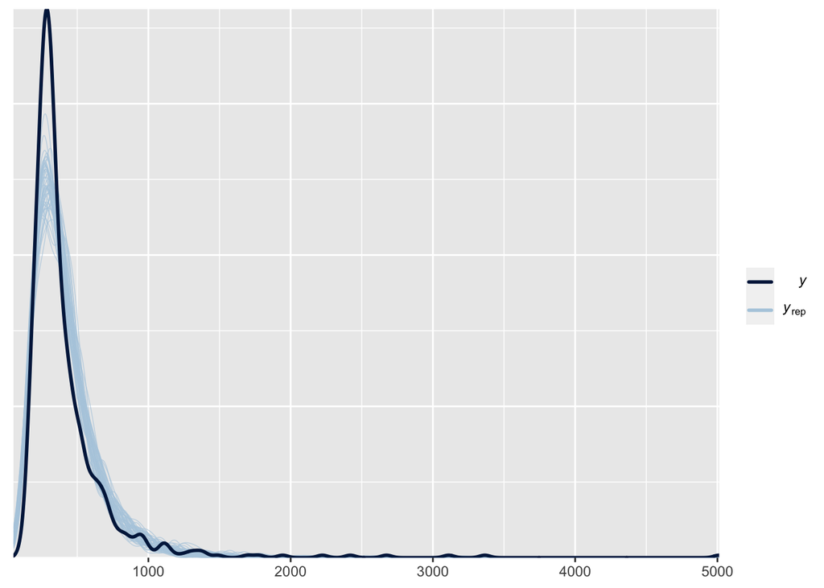

```r
pp_check(fit_df_gg05_rc, ndraws = 50, type = "dens_overlay")
```

- now by participants

[figure not shown]

```r
ppc_dens_overlay_grouped(df_gg05_rc$RT,
  yrep =
    posterior_predict(fit_df_gg05_rc,
      ndraws = 100
    ),
  group = df_gg05_rc$subj
) +
  xlab("Signal in the N400 spatiotemporal window")
```

- and by sd

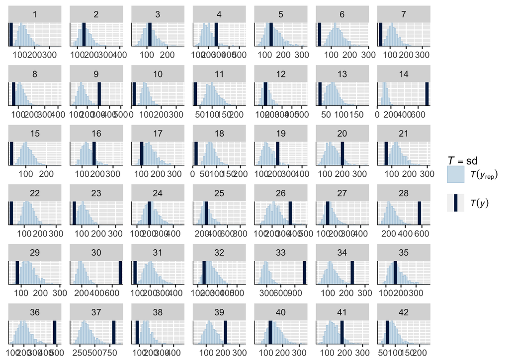

```r
pp_check(fit_df_gg05_rc,
  type = "stat_grouped",
  ndraws = 1000,
  group = "subj",
  stat = "sd"
)
```

```r
posterior_summary(fit_df_gg05_rc, variable = "b_condition1")
```

```
              Estimate  Est.Error        Q2.5     Q97.5
b_condition1 0.1002225 0.04665774 0.006247148 0.1909658
```

```r
posterior_summary(fit_df_gg05_rc, variable = "b_Intercept")
```

```
            Estimate  Est.Error     Q2.5    Q97.5
b_Intercept 5.877558 0.05381118 5.773629 5.982502
```

- our posteriors are pretty close to our priors

```r
brms::prior_summary(fit_df_gg05_rc)
```

```
                prior     class       coef group resp dpar nlpar lb ub
       normal(0, 0.1)         b
       normal(0, 0.1)         b condition1
       normal(6, 1.5) Intercept
 lkj_corr_cholesky(2)         L
 lkj_corr_cholesky(2)         L             item
 lkj_corr_cholesky(2)         L             subj
         normal(0, 1)        sd                                   0
         normal(0, 1)        sd             item                  0
         normal(0, 1)        sd condition1  item                  0
         normal(0, 1)        sd  Intercept  item                  0
         normal(0, 1)        sd             subj                  0
         normal(0, 1)        sd condition1  subj                  0
         normal(0, 1)        sd  Intercept  subj                  0
         normal(0, 1)     sigma                                   0
       source
         user
 (vectorized)
         user
         user
 (vectorized)
 (vectorized)
         user
 (vectorized)
 (vectorized)
 (vectorized)
 (vectorized)
 (vectorized)
 (vectorized)
         user
```

- let’s see if this is due to the influence of our priors. Let’s start with *narrower* prior

$$\beta \sim Normal(0,.01)$$

```r
fit_df_gg05_rc_tight <-
  brm(
    RT ~ condition + (condition |
                     subj) + (condition | item),
    family = lognormal(),
    prior =
      c(
        prior(normal(6, 1.5), class = Intercept),
        prior(normal(0, .01), class = b),
        prior(normal(0, 1), class = sigma),
        prior(normal(0, 1), class = sd),
        prior(lkj(2), class = cor)
      ),
    data = df_gg05_rc
  )

fit_df_gg05_rc_tight
```

```
 Family: lognormal
  Links: mu = identity; sigma = identity
Formula: RT ~ condition + (condition | subj) + (condition | item)
   Data: df_gg05_rc (Number of observations: 672)
  Draws: 4 chains, each with iter = 2000; warmup = 1000; thin = 1;
         total post-warmup draws = 4000

Group-Level Effects:
~item (Number of levels: 16)
                          Estimate Est.Error l-95% CI u-95% CI Rhat Bulk_ESS
sd(Intercept)                 0.04      0.02     0.00     0.09 1.00     1110
sd(condition1)                0.11      0.05     0.02     0.22 1.00     1219
cor(Intercept,condition1)     0.30      0.39    -0.58     0.89 1.00     1055
                          Tail_ESS
sd(Intercept)                 1105
sd(condition1)                1210
cor(Intercept,condition1)     1687

~subj (Number of levels: 42)
                          Estimate Est.Error l-95% CI u-95% CI Rhat Bulk_ESS
sd(Intercept)                 0.33      0.04     0.26     0.43 1.00      737
sd(condition1)                0.24      0.04     0.16     0.34 1.00     1429
cor(Intercept,condition1)     0.52      0.16     0.17     0.78 1.00     1175
                          Tail_ESS
sd(Intercept)                 1284
sd(condition1)                2175
cor(Intercept,condition1)     2236

Population-Level Effects:
           Estimate Est.Error l-95% CI u-95% CI Rhat Bulk_ESS Tail_ESS
Intercept      5.84      0.05     5.74     5.95 1.01      364     1007
condition1     0.00      0.01    -0.02     0.02 1.00     4559     3051

Family Specific Parameters:
      Estimate Est.Error l-95% CI u-95% CI Rhat Bulk_ESS Tail_ESS
sigma     0.36      0.01     0.34     0.38 1.00     3426     2509

Draws were sampled using sampling(NUTS). For each parameter, Bulk_ESS
and Tail_ESS are effective sample size measures, and Rhat is the potential
scale reduction factor on split chains (at convergence, Rhat = 1).
```

```r
posterior_summary(fit_df_gg05_rc_tight, variable = "b_condition1")
```

```
                Estimate   Est.Error        Q2.5      Q97.5
b_condition1 0.004111086 0.009841477 -0.01529765 0.02310622
```

- and now a *wider* prior

$$\beta \sim Normal(0,1)$$

```r
fit_df_gg05_rc_wide <-
  brm(
    RT ~ condition + (condition |
                     subj) + (condition | item),
    family = lognormal(),
    prior =
      c(
        prior(normal(6, 1.5), class = Intercept),
        prior(normal(0, 1), class = b),
        prior(normal(0, 1), class = sigma),
        prior(normal(0, 1), class = sd),
        prior(lkj(2), class = cor)
      ),
    data = df_gg05_rc
  )

fit_df_gg05_rc_wide
```

```
 Family: lognormal
  Links: mu = identity; sigma = identity
Formula: RT ~ condition + (condition | subj) + (condition | item)
   Data: df_gg05_rc (Number of observations: 672)
  Draws: 4 chains, each with iter = 2000; warmup = 1000; thin = 1;
         total post-warmup draws = 4000

Group-Level Effects:
~item (Number of levels: 16)
                          Estimate Est.Error l-95% CI u-95% CI Rhat Bulk_ESS
sd(Intercept)                 0.04      0.02     0.00     0.09 1.00     1324
sd(condition1)                0.09      0.05     0.01     0.19 1.00     1014
cor(Intercept,condition1)     0.28      0.41    -0.62     0.90 1.00     1691
                          Tail_ESS
sd(Intercept)                 1513
sd(condition1)                1094
cor(Intercept,condition1)     2247

~subj (Number of levels: 42)
                          Estimate Est.Error l-95% CI u-95% CI Rhat Bulk_ESS
sd(Intercept)                 0.33      0.04     0.26     0.41 1.00      927
sd(condition1)                0.23      0.04     0.15     0.31 1.00     1647
cor(Intercept,condition1)     0.50      0.16     0.14     0.78 1.00     1995
                          Tail_ESS
sd(Intercept)                 1417
sd(condition1)                2598
cor(Intercept,condition1)     2539

Population-Level Effects:
           Estimate Est.Error l-95% CI u-95% CI Rhat Bulk_ESS Tail_ESS
Intercept      5.88      0.05     5.77     5.98 1.01      574      915
condition1     0.12      0.05     0.02     0.22 1.00     1598     2304

Family Specific Parameters:
      Estimate Est.Error l-95% CI u-95% CI Rhat Bulk_ESS Tail_ESS
sigma     0.36      0.01     0.34     0.38 1.00     3258     2949

Draws were sampled using sampling(NUTS). For each parameter, Bulk_ESS
and Tail_ESS are effective sample size measures, and Rhat is the potential
scale reduction factor on split chains (at convergence, Rhat = 1).
```

```r
posterior_summary(fit_df_gg05_rc_wide, variable = "b_condition1")
```

```
              Estimate  Est.Error       Q2.5     Q97.5
b_condition1 0.1210669 0.05163154 0.01964035 0.2244496
```

```r
prior <- data.frame(posterior_summary(fit_df_gg05_rc, variable = "b_condition1")) %>%
  mutate("Prior for $\\beta$" = "Normal(0,.1)")
tight <- data.frame(posterior_summary(fit_df_gg05_rc_tight, variable = "b_condition1")) %>%
  mutate("Prior for $\\beta$" = "Normal(0,.01)")
wide <- data.frame(posterior_summary(fit_df_gg05_rc_wide, variable = "b_condition1")) %>%
  mutate("Prior for $\\beta$" = "Normal(0,1)")

sens_priors <- rbind(prior,tight,wide)

brms::prior_summary(fit_df_gg05_rc_wide)
```

```
                prior     class       coef group resp dpar nlpar lb ub
         normal(0, 1)         b
         normal(0, 1)         b condition1
       normal(6, 1.5) Intercept
 lkj_corr_cholesky(2)         L
 lkj_corr_cholesky(2)         L             item
 lkj_corr_cholesky(2)         L             subj
         normal(0, 1)        sd                                   0
         normal(0, 1)        sd             item                  0
         normal(0, 1)        sd condition1  item                  0
         normal(0, 1)        sd  Intercept  item                  0
         normal(0, 1)        sd             subj                  0
         normal(0, 1)        sd condition1  subj                  0
         normal(0, 1)        sd  Intercept  subj                  0
         normal(0, 1)     sigma                                   0
       source
         user
 (vectorized)
         user
         user
 (vectorized)
 (vectorized)
         user
 (vectorized)
 (vectorized)
 (vectorized)
 (vectorized)
 (vectorized)
 (vectorized)
         user
```

```r
sens_priors %>%
  kbl() %>%
  kable_styling()
```

|  | Estimate | Est.Error | Q2.5 | Q97.5 | Prior for $\beta$ |
| --- | --- | --- | --- | --- | --- |
| b_condition1 | 0.1002225 | 0.0466577 | 0.0062471 | 0.1909658 | Normal(0,.1) |
| b_condition11 | 0.0041111 | 0.0098415 | -0.0152977 | 0.0231062 | Normal(0,.01) |
| b_condition12 | 0.1210669 | 0.0516315 | 0.0196403 | 0.2244496 | Normal(0,1) |

- and now in milliseconds

```r
alpha1 <- as_draws_df(fit_df_gg05_rc)$b_Intercept
beta1 <- as_draws_df(fit_df_gg05_rc)$b_condition1
diff1 <- exp(alpha1 + beta1/2) - exp(alpha1 - beta1/2)
prior_ms <- data.frame(mean = mean(diff1), quantile(diff1, .025), quantile(diff1, .975), row.names = NULL) %>%
  rename("Estimate (ms)" = "mean",
         "2.5%" = "quantile.diff1..0.025.",
         "97.5%" = "quantile.diff1..0.975.")%>%
  mutate("Prior for $\\beta$" = "Normal(0,.1)")

alpha1 <- as_draws_df(fit_df_gg05_rc_tight)$b_Intercept
beta1 <- as_draws_df(fit_df_gg05_rc_tight)$b_condition1
diff1 <- exp(alpha1 + beta1/2) - exp(alpha1 - beta1/2)
tight_ms <- data.frame(mean = mean(diff1), quantile(diff1, .025), quantile(diff1, .975), row.names = NULL) %>%
  rename("Estimate (ms)" = "mean",
         "2.5%" = "quantile.diff1..0.025.",
         "97.5%" = "quantile.diff1..0.975.")%>%
  mutate("Prior for $\\beta$" = "Normal(0,.01)")

alpha1 <- as_draws_df(fit_df_gg05_rc_wide)$b_Intercept
beta1 <- as_draws_df(fit_df_gg05_rc_wide)$b_condition1
diff1 <- exp(alpha1 + beta1/2) - exp(alpha1 - beta1/2)
wide_ms <- data.frame(mean = mean(diff1), quantile(diff1, .025), quantile(diff1, .975), row.names = NULL) %>%
  rename("Estimate (ms)" = "mean",
         "2.5%" = "quantile.diff1..0.025.",
         "97.5%" = "quantile.diff1..0.975.") %>%
  mutate("Prior for $\\beta$" = "Normal(0,1)")


priors_ms <- rbind(prior_ms,tight_ms,wide_ms) %>%
  mutate(effect = "b_condition1") %>%
  relocate(effect, .before="Estimate (ms)")

priors_ms %>%
  kbl() %>%
  kable_styling()
```

| effect | Estimate (ms) | 2.5% | 97.5% | Prior for $\beta$ |
| --- | --- | --- | --- | --- |
| b_condition1 | 36.164531 | 2.218118 | 71.291773 | Normal(0,.1) |
| b_condition1 | 1.417525 | -5.303022 | 8.053658 | Normal(0,.01) |
| b_condition1 | 43.737250 | 6.598282 | 83.369345 | Normal(0,1) |

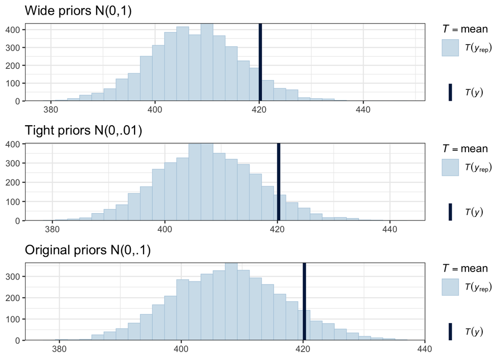

```r
# these are all the intercept, i'm interested in the slope though :/
ggpubr::ggarrange(
  pp_check(fit_df_gg05_rc_wide, type = "stat") + theme_bw() + ggtitle("Wide priors N(0,1)"),
  pp_check(fit_df_gg05_rc_tight, type = "stat") + theme_bw() + ggtitle("Tight priors N(0,.01)"),
  pp_check(fit_df_gg05_rc, type = "stat") + theme_bw() + ggtitle("Original priors N(0,.1)"),
nrow = 3
)
```

## 5.3 Exercise 5.3 Relative clause processing in Mandarin Chinese

Load the following two data sets:

```r
data("df_gibsonwu")
data("df_gibsonwu2")
```

The data are taken from two experiments that investigate (inter alia) the effect of relative clause type on reading time in Chinese. The data are from Gibson and Wu (2013) and Vasishth et al. (2013) respectively. The second data set is a direct replication attempt of the Gibson and Wu (2013) experiment.

Chinese relative clauses are interesting theoretically because they are prenominal: the relative clause appears before the head noun. For example, the English relative clauses shown above would appear in the following order in Mandarin. The square brackets mark the relative clause, and REL refers to the Chinese equivalent of the English relative pronoun who.

(2a) [The photographer sent to the editor] REL the reporter was hoping for a good story. (ORC)

(2b) [sent the photographer to the editor] REL the reporter who was hoping for a good story. (SRC)

As discussed in Gibson and Wu (2013), the consequence of Chinese relative clauses being prenominal is that the distance between the verb in relative clause and the head noun is larger in subject relatives than object relatives. Hsiao and Gibson (2003) were the first to suggest that the larger distance in subject relatives leads to longer reading time at the head noun. Under this view, the prediction is that subject relatives are harder to process than object relatives. If this is true, this is interesting and surprising because in most other languages that have been studied, subject relatives are easier to process than object relatives; so Chinese will be a very unusual exception cross-linguistically.

The data provided are for the critical region (the head noun; here, reporter). The experiment method is self-paced reading, so we have reading times in milliseconds. The second data set is a direct replication attempt of the first data set, which is from Gibson and Wu (2013).

The research hypothesis is whether the difference in reading times between object and subject relative clauses is negative. For the first data set (`df_gibsonwu`), investigate this question by fitting two “maximal” hierarchical models (correlated varying intercept and slopes for subjects and items). The dependent variable in both models is the raw reading time in milliseconds. The first model should use the normal likelihood in the model; the second model should use the log-normal likelihood. In both models, use $\pm 0.5$ sum coding to model the effect of relative clause type. You will need to decide on appropriate priors for the various parameters.

**Tip**

#Contrasts

- `obj-ext = -0.5`, `subj-ext = 0.5`

```r
head(df_gibsonwu)
```

```
    subj item     type   rt
94     1   13  obj-ext 1561
221    1    6 subj-ext  959
341    1    5  obj-ext  582
461    1    9  obj-ext  294
621    1   14 subj-ext  438
753    1    4 subj-ext  286
```

```r
df_gibsonwu$type <- factor(df_gibsonwu$type, levels = c("obj-ext","subj-ext"))

contrasts(df_gibsonwu$type) <- c(-0.5,+0.5)
contrasts(df_gibsonwu$type)
```

```
         [,1]
obj-ext  -0.5
subj-ext  0.5
```

# 6 Normal likelihood

- first set priors

```r
priors_gw_norm <- c(
  set_prior("normal(500, 150)", class = "Intercept"),
  set_prior("normal(0,500)", class = "b", coef = "type1"),
  set_prior("normal(0,500)", class = "sd"),
  set_prior("normal(0,1000)",class = "sigma"),
  set_prior("lkj(2)", class = "cor")
)
```

- fit model

```r
fit_gw_norm <- brm(rt ~ 1 + type +
                   (1 + type | subj),
                 data = df_gibsonwu,
                 family = gaussian(),
                 prior = priors_gw_norm)
```

[output not shown]

# 7 Log-normal likelihood

```r
priors_gw_log <- c(
  set_prior("normal(6, 1.5)", class = "Intercept"),
  set_prior("normal(0,1)", class = "b", coef = "type1"),
  set_prior("normal(0,1)",class = "sd"),
  set_prior("normal(0,1)",class = "sigma"),
  set_prior("lkj(2)", class = "cor")
)
```

- fit model

```r
fit_gw_log <- brm(rt ~ 1 + type +
                   (1 + type | subj),
                 data = df_gibsonwu,
                 family = lognormal(),
                 prior = priors_gw_log)
```

[output not shown]

1. Plot the posterior predictive distributions from the two models. What is the difference in the posterior predictive distributions of the two models; and why is there a difference?

**Posterior predictive distirbutions**

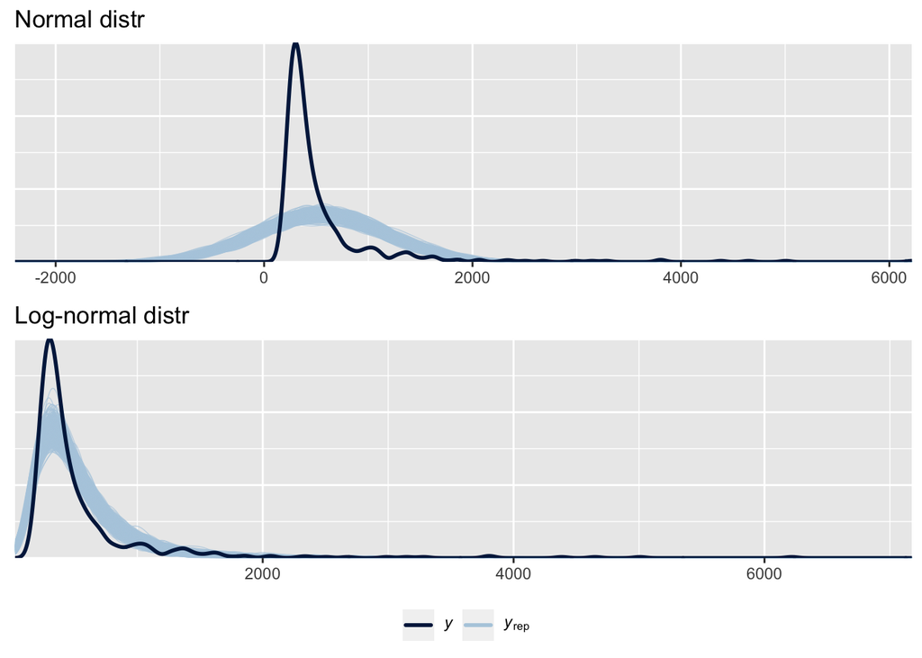

```r
ggpubr::ggarrange(
  pp_check(fit_gw_norm, ndraws = 1000) +
    ggtitle("Normal distr") +
    theme(legend.position = "none"),
  pp_check(fit_gw_log, ndraws = 1000) +
    ggtitle("Log-normal distr") +
    theme(legend.position = "none"),
  cowplot::get_legend(pp_check(fit_gw_log) +
                        theme(legend.position = "bottom")),
  ncol = 1,
  heights = c(.45,.45,.1)
)
```

- quite a mismatch in normal likelihood model, e.g., negative values are generated
- log-normal better fit
2. Examine the posterior distributions of the effect estimates (in milliseconds) in the two models. Why are these different?

**Tip**

3. Given the posterior predictive distributions you plotted above, why is the log-normal likelihood model better for carrying out inference and hypothesis testing?

**Tip**

Next, work out a normal approximation of the log-normal model’s posterior distribution for the relative clause effect that you obtained from the above data analysis. Then use that normal approximation as an informative prior for the slope parameter when fitting a hierarchical model to the second data set. This is an example of incrementally building up knowledge by successively using a previous study’s posterior as a prior for the next study; this is essentially equivalent to pooling both data sets (check that pooling the data and using a Normal(0,1) prior for the effect of interest, with a log-normal likelihood, gives you approximately the same posterior as the informative-prior model fit above).

## 7.1 Exercise 5.4

## 7.2 Exercise 5.5

## 7.3 Exercise 5.6

## 7.4 Exercise 5.7

## 7.5 Exercise 5.8